# Simulation Study: Analysing the performance of Hierarchical Clustering for Detecting the Number of Views

2025-07-26

# Executive Summary

This simulation study extends our analysis to investigate how accurately hierarchical clustering performs in determining the number of views. We test whether the approach is accurate for 2 structures (our baseline). 3, 4, and 5 independent structures, all embedded in 10-,100-, and 500-dimensional data. We systematically vary the separation factor to examine how differing levels of cluster distinctness affect performance.

**Key Questions:** 1. How accurately does hierarchical clustering detect the number of distinct clustering structures embedded in high-dimensional data? 2. How does performance change as the number of independent structures increases? 3. What level of cluster separation is required to reliably identify multiple views? 4. Is there a threshold beyond which hierarchical clustering consistently under- or over-estimates the true number of structures?

# Implementation

## 1. Methods

### 1.1 Experimental Design

We use data divided equally among k structures: **p=10** - **k=2**: 5 dimensions per structure (baseline) - **k=3**: 3-4 dimensions per structure - **k=4**: 2-3 dimensions per structure  
- **k=5**: 2 dimensions per structure **p=100** - **k=2**: 50 dimensions per structure (baseline) - **k=3**: 33-34 dimensions per structure - **k=4**: 25 dimensions per structure  
- **k=5**: 20 dimensions per structure **p=500** - **k=2**: 250 dimensions per structure (baseline) - **k=3**: 166-167 dimensions per structure - **k=4**: 125 dimensions per structure  
- **k=5**: 100 dimensions per structure

Each structure has a different number of clusters (3, 4, 5, 6, or 7) to ensure distinguishability.

### Experimental Grid:

Total: 108 conditions × 25 replications = 2700 runs

## 2. Implementation

```r
# Load required libraries
library(mvtnorm)      # For multivariate normal data generation
library(cluster)      # For PAM clustering
library(mclust)       # For model-based clustering
library(NbClust)      # For choosing optimal number of clusters
library(otrimle)      # For otrimle
```

```r
library(ggplot2)      # For visualisation
library(dplyr)        # For data manipulation
library(tidyr)        # For data reshaping
library(viridis)      # For colour scales
library(gridExtra)    # For arranging plots
library(foreach)      # For parallel loops
library(doParallel)   # For parallel backend
library(parallel)     # For makeCluster and stopCluster
library(R.utils)      # For mclust timeout
# Set seed for reproducibility
set.seed(42)
```

```r
# Note: Parallel cluster will be created within the simulation chunk
# to ensure proper scoping in R Markdown environment

cat("Parallel processing configuration:\n")
```

```
## Parallel processing configuration:
```

```r
cat("- Total cores available:", detectCores(), "\n")
```

```
## - Total cores available: 8
```

```r
cat("- Cores to be used:", detectCores() - 2, "\n")
```

```
## - Cores to be used: 6
```

```r
cat("- Cores kept free for system:", 2, "\n\n")
```

```
## - Cores kept free for system: 2
```

```r
# Set up caching directory
cache_dir <- "~/Documents/MPhil Population Health Sciences/Dissertation/GMM Simulation Study/hclust_cache"
if (!dir.exists(cache_dir)) {
  dir.create(cache_dir)
  cat("Created cache directory:", cache_dir, "\n")
} else {
  cat("Using existing cache directory:", cache_dir, "\n")
}
```

```
## Using existing cache directory: ~/Documents/MPhil Population Health Sciences/Dissertation/GMM Simulation Study/hclust_cache
```

```r
# Cache functions
get_cache_filename <- function(n_structures, p_dims, n_samples, separation_factor) {
  filename <- sprintf("results_k%d_d%d_n%d_sep%.1f.rds", n_structures, p_dims, n_samples, separation_factor)
  file.path(cache_dir, filename)
}

check_condition_cache <- function(n_structures, p_dims, n_samples, separation_factor) {
  cache_file <- get_cache_filename(n_structures, p_dims, n_samples, separation_factor)
  file.exists(cache_file)
}

save_condition_results <- function(results, n_structures, p_dims, n_samples, separation_factor) {
  cache_file <- get_cache_filename(n_structures, p_dims, n_samples, separation_factor)
  cat("Attempting to save results to:", cache_file, "\n")
  saveRDS(results, cache_file)
  cat("Successfully saved results to:", cache_file, "\n")
}

load_condition_results <- function(n_structures, p_dims, n_samples, separation_factor) {
  cache_file <- get_cache_filename(n_structures, p_dims, n_samples, separation_factor)
  if (file.exists(cache_file)) {
    return(readRDS(cache_file))
  } else {
    return(NULL)
  }
}

get_all_results_cache_filename <- function() {
  file.path(cache_dir, "all_results_full.rds")
}
```

```r
# Experimental parameters
n_structures_values <- c(2, 3, 4, 5)
p_dims <- c(10, 100, 500)
sample_sizes <- c(250, 500, 1000)
separation_factors <- c(6.0, 3.0, 1.5)
n_replications <- 25

# Fixed parameters
cluster_variance <- 0.3

# Clusters per structure (different for each to ensure distinguishability)
clusters_per_structure <- c(3, 4, 5, 6, 7)  # Will use first k of these

# Total conditions
n_conditions <- length(p_dims) * length(n_structures_values) * length(sample_sizes) * length(separation_factors)

cat("\nExperimental design:\n")
```

```
##
## Experimental design:
```

```r
cat("- Number of structures (k):", paste(n_structures_values, collapse=", "), "\n")
```

```
## - Number of structures (k): 2, 3, 4, 5
```

```r
cat("- Total dimensions:", paste(p_dims, collapse=", "), "\n")
```

```
## - Total dimensions: 10, 100, 500
```

```r
cat("- Sample sizes:", paste(sample_sizes, collapse=", "), "\n")
```

```
## - Sample sizes: 250, 500, 1000
```

```r
cat("- Separation factors: ", paste(separation_factors, "σ", sep="", collapse=", "), "\n")
```

```
## - Separation factors:  6σ, 3σ, 1.5σ
```

```r
cat("- Total conditions:", n_conditions, "\n")
```

```
## - Total conditions: 108
```

```r
cat("- Replications per condition:", n_replications, "\n")
```

```
## - Replications per condition: 25
```

```r
cat("- Total simulation runs:", n_conditions * n_replications, "\n")
```

```
## - Total simulation runs: 2700
```

```r
# Generate cluster means for k structures
generate_cluster_means_k <- function(separation_factor, cluster_variance, n_structures, dims_list) {
  base_separation <- separation_factor * sqrt(cluster_variance)

  all_means <- list()

  for (k in 1:n_structures) {
    n_clusters <- clusters_per_structure[k]
    n_dims <- dims_list[k]

    # Generate means for this structure
    structure_means <- list()
    for (c in 1:n_clusters) {
      # Create distinct patterns for each cluster
      if (c <= 2) {
        # First two clusters: opposite sides
        multiplier <- ifelse(c == 1, -1, 1)
        means <- runif(n_dims, 0.8, 1.5) * multiplier * base_separation
      } else {
        # Additional clusters: random positions
        means <- runif(n_dims, -0.7, 0.7) * base_separation
        # Add some structure to avoid complete overlap
        means <- means + (c - 2.5) * 0.3 * base_separation
      }
      structure_means[[paste0("cluster_", c)]] <- means
    }

    all_means[[paste0("structure_", k)]] <- structure_means
  }

  return(all_means)
}

# Generate dataset with k structures
generate_dataset_k <- function(p_dim, separation_factor, cluster_variance, n_samples, n_structures, dims_list) {

  # Generate cluster assignments for each structure
  cluster_assignments <- list()
  for (k in 1:n_structures) {
    n_clusters <- clusters_per_structure[k]
    # Use different proportions for each structure
    props <- diff(c(0, sort(runif(n_clusters-1)), 1))
    cluster_assignments[[k]] <- sample(1:n_clusters, n_samples, replace = TRUE, prob = props)
  }

  # Get cluster means
  all_means <- generate_cluster_means_k(separation_factor, cluster_variance, n_structures, dims_list)

  # Initialize data matrix
  data_matrix <- matrix(NA, nrow = n_samples, ncol = sum(dims_list))

  # Generate data for each structure
  col_start <- 1
  for (k in 1:n_structures) {
    n_dims <- dims_list[k]
    col_end <- col_start + n_dims - 1

    structure_means <- all_means[[paste0("structure_", k)]]

    # Generate data for this structure
    for (i in 1:n_samples) {
      cluster_id <- cluster_assignments[[k]][i]
      cluster_mean <- structure_means[[paste0("cluster_", cluster_id)]]
      cluster_cov <- diag(rep(cluster_variance, n_dims))

      data_matrix[i, col_start:col_end] <- mvtnorm::rmvnorm(1, mean = cluster_mean, sigma = cluster_cov)
    }

    col_start <- col_end + 1
  }

  return(list(
    data = data_matrix,
    true_assignments = cluster_assignments,
    dims_list = dims_list
  ))
}
```

```r
# Analyze dataset with k structures
analyze_dataset_k <- function(data_matrix, n_structures, separation_factor, dims_list) {
  n_dims <- ncol(data_matrix)

  # Step 1: Mclust clustering for each dimension
  cluster_assignments <- matrix(NA, nrow = nrow(data_matrix), ncol = n_dims)
  for(i in 1:n_dims) {
    mclust_fit <- Mclust(data_matrix[, i], G = 1:9, verbose = FALSE)
    cluster_assignments[, i] <- mclust_fit$classification
  }

  # Step 2: Compute dissimilarity matrix based on ARI
  ari_matrix <- matrix(1, n_dims, n_dims)
  for(i in 1:(n_dims - 1)) {
    for(j in (i + 1):n_dims) {
      ari_val <- adjustedRandIndex(cluster_assignments[, i], cluster_assignments[, j])
      ari_matrix[i, j] <- ari_val
      ari_matrix[j, i] <- ari_val
    }
  }
  dis_mat <- 1 - ari_matrix
  dist_mat <- as.dist(dis_mat)

  # Step 3: Try various linkage + index combinations
  linkage_methods <- c("average", "complete", "ward.D", "ward.D2", "single", "mcquitty", "median", "centroid")
  nbclust_indices <- c("silhouette", "dunn", "cindex", "mcclain")

  results <- list()

  for (linkage in linkage_methods) {
    hc <- hclust(dist_mat, method = linkage)

    for (index in nbclust_indices) {
      res <- tryCatch({
        nb <- NbClust(data = NULL,
                      diss = dist_mat,
                      distance = NULL,
                      method = linkage,
                      min.nc = 2,
                      max.nc = 5,
                      index = index)

        best_k <- if (!is.null(nb$Best.nc)) as.numeric(nb$Best.nc[1]) else NA

        data.frame(
          tns = n_structures,
          sep_fact = separation_factor,
          method = linkage,
          index = index,
          optimal_k = best_k,
          correct = (n_structures == best_k),
          stringsAsFactors = FALSE
        )
      }, error = function(e) {
        data.frame(
          tns = n_structures,
          sep_fact = separation_factor,
          method = linkage,
          index = index,
          optimal_k = NA,
          correct = NA,
          stringsAsFactors = FALSE
        )
      })

      results[[length(results) + 1]] <- res
    }
  }

  # Combine all results
  df <- do.call(rbind, results)
  return(df)
}

# Wrapper function for parallel execution
run_single_replication <- function(p_dim, rep, n_structures, separation_factor, n_samples, dims_list) {
  # Generate dataset
  dataset <- generate_dataset_k(p_dim, separation_factor, cluster_variance, n_samples, n_structures, dims_list)

  # Analyze dataset
  analysis_result <- analyze_dataset_k(dataset$data, n_structures, separation_factor, dims_list)

  # Add metadata to result
  analysis_result$p_dims <- p_dim
  analysis_result$n_samples <- n_samples
  analysis_result$replication <- rep
  return(analysis_result)
}
```

# 3. Simulation

```r
library(foreach)
library(doParallel)
library(dplyr)

cat("Starting simulation chunk\n")
```

```
## Starting simulation chunk
```

```r
# Number of cores for parallel (leave 2 free)
n_cores <- max(1, parallel::detectCores() - 2)

# Initialize cluster
cl <- makeCluster(n_cores)
registerDoParallel(cl)

# Build full grid of conditions
conditions_grid <- expand.grid(
  n_structures = n_structures_values,
  p_dim = p_dims,
  n_samples = sample_sizes,
  separation_factor = separation_factors
)

# Check which conditions already have cached results
conditions_grid$cached <- mapply(
  check_condition_cache,
  conditions_grid$n_structures,
  conditions_grid$p_dim,
  conditions_grid$n_samples,
  conditions_grid$separation_factor
)

# Select only those conditions that are not cached
to_run <- subset(conditions_grid, cached == FALSE)

if (nrow(to_run) == 0) {
  message("✅ All simulation results are already cached.")
} else {
  message("🚀 Running uncached simulation conditions.")

  foreach(i = 1:nrow(to_run),
          .packages = c("mvtnorm", "cluster", "mclust", "NbClust", "otrimle", "dplyr"),
          .errorhandling = 'pass',
          .verbose = TRUE) %dopar% {

    cond <- to_run[i, ]
    # Dynamically compute dims per structure based on total p
    dims_list <- rep(floor(cond$p_dim / cond$n_structures), cond$n_structures)
    remainder <- cond$p_dim %% cond$n_structures
    if (remainder > 0) {
      dims_list[1:remainder] <- dims_list[1:remainder] + 1
    }

    # ✅ Print dims_list for verification
    cat(sprintf("dims_list for p = %d and k = %d: [%s]\n",
                cond$p_dim, cond$n_structures,
                paste(dims_list, collapse = ", ")))



    rep_results <- lapply(1:n_replications, function(rep) {
      run_single_replication(
        p_dim = cond$p_dim,
        rep = rep,
        n_structures = cond$n_structures,
        separation_factor = cond$separation_factor,
        n_samples = cond$n_samples,
        dims_list = dims_list
      )
    })

    rep_results <- Filter(Negate(is.null), rep_results)

    # ✅ Flatten to a single data frame for the condition
    combined_results <- do.call(rbind, rep_results)

    # ✅ Save the flat data frame (not the list) to RDS
    save_condition_results(combined_results,
                           cond$n_structures,
                           cond$p_dim,
                           cond$n_samples,
                           cond$separation_factor)
  }
}

stopCluster(cl)

# ✅ Load and flatten all cached results
all_results_files <- list.files(cache_dir, pattern = "results_k.*\\.rds$", full.names = TRUE)

all_conditions_results <- lapply(all_results_files, function(file) {
  result_df <- tryCatch(readRDS(file), error = function(e) NULL)
  if (!is.null(result_df) && is.data.frame(result_df)) {
    result_df
  } else if (is.list(result_df)) {
    do.call(rbind, result_df)
  } else {
    NULL
  }
})

# ✅ Remove any failed reads or empty items
all_conditions_results <- Filter(Negate(is.null), all_conditions_results)

# ✅ Combine all into a master data frame
all_results_df <- do.call(rbind, all_conditions_results)

message("✅ Simulation complete. Total rows: ", nrow(all_results_df))
```

# 4. Results

```r
library(dplyr)
library(ggplot2)
library(viridis)
library(tidyr)
library(tools)

# ---- Base Summaries ----
linkage_summary <- summary_perf %>%
  group_by(method) %>%
  summarise(mean_accuracy = mean(mean_accuracy, na.rm = TRUE),
            sd_accuracy = sd(mean_accuracy, na.rm = TRUE),
            n = n(),
            .groups = "drop") %>%
  arrange(desc(mean_accuracy))
cat("### Accuracy Summary by Linkage Method\n")
```

```
## ### Accuracy Summary by Linkage Method
```

```r
print(linkage_summary, n = Inf)
```

```
## # A tibble: 7 × 4
##   method                  mean_accuracy sd_accuracy     n
##   <chr>                           <dbl>       <dbl> <int>
## 1 Ward's minimum variance         0.321          NA   432
## 2 McQuitty                        0.317          NA   432
## 3 Complete                        0.316          NA   432
## 4 Single                          0.313          NA   432
## 5 Average                         0.313          NA   432
## 6 Median                          0.268          NA   432
## 7 Centroid                        0.264          NA   432
```

```r
cat("\n\n")
```

```r
index_summary <- summary_perf %>%
  group_by(index) %>%
  summarise(mean_accuracy = mean(mean_accuracy, na.rm = TRUE),
            sd_accuracy = sd(mean_accuracy, na.rm = TRUE),
            n = n(),
            .groups = "drop") %>%
  arrange(desc(mean_accuracy))
cat("### Accuracy Summary by Index\n")
```

```
## ### Accuracy Summary by Index
```

```r
print(index_summary, n = Inf)
```

```
## # A tibble: 4 × 4
##   index      mean_accuracy sd_accuracy     n
##   <chr>              <dbl>       <dbl> <int>
## 1 Dunn               0.378          NA   756
## 2 Silhouette         0.368          NA   756
## 3 C-Index            0.258          NA   756
## 4 McClain            0.203          NA   756
```

```r
cat("\n\n")
```

```r
combo_summary <- summary_perf %>%
  group_by(method, index) %>%
  summarise(mean_accuracy = mean(mean_accuracy, na.rm = TRUE),
            sd_accuracy = sd(mean_accuracy, na.rm = TRUE),
            n = n(),
            .groups = "drop") %>%
  arrange(desc(mean_accuracy))
cat("### Accuracy Summary by Linkage-Index Combination\n")
```

```
## ### Accuracy Summary by Linkage-Index Combination
```

```r
print(combo_summary, n = Inf)
```

```
## # A tibble: 28 × 5
##    method                  index      mean_accuracy sd_accuracy     n
##    <chr>                   <chr>              <dbl>       <dbl> <int>
##  1 Ward's minimum variance Dunn               0.425          NA   108
##  2 Complete                Dunn               0.421          NA   108
##  3 Single                  Silhouette         0.411          NA   108
##  4 McQuitty                Silhouette         0.402          NA   108
##  5 Average                 Dunn               0.400          NA   108
##  6 McQuitty                Dunn               0.399          NA   108
##  7 Ward's minimum variance Silhouette         0.397          NA   108
##  8 Average                 Silhouette         0.393          NA   108
##  9 Single                  Dunn               0.386          NA   108
## 10 Complete                Silhouette         0.376          NA   108
## 11 Centroid                Dunn               0.307          NA   108
## 12 Median                  Dunn               0.306          NA   108
```

[output cut: 16 more lines]

```r
cat("\n\n")
```

```r
# ---- Loop: By Dimension ----
for (d in sort(unique(summary_perf$p_dims))) {
  cat(paste0("### Accuracy Summary for Dimension p = ", d, "\n"))
  dim_d_summary <- summary_perf %>%
    filter(p_dims == d) %>%
    group_by(method, index) %>%
    summarise(mean_accuracy = mean(mean_accuracy, na.rm = TRUE),
              sd_accuracy = sd(mean_accuracy, na.rm = TRUE),
              n = n(),
              .groups = "drop") %>%
    arrange(desc(mean_accuracy))
  print(dim_d_summary, n = Inf)
  cat("\n\n")
}
```

```
## ### Accuracy Summary for Dimension p = 10
## # A tibble: 28 × 5
##    method                  index      mean_accuracy sd_accuracy     n
##    <chr>                   <chr>              <dbl>       <dbl> <int>
##  1 Complete                Dunn               0.466          NA    36
##  2 Average                 Dunn               0.457          NA    36
##  3 McQuitty                Dunn               0.457          NA    36
##  4 Ward's minimum variance Dunn               0.456          NA    36
##  5 Single                  Dunn               0.449          NA    36
##  6 Median                  Dunn               0.371          NA    36
##  7 Centroid                Dunn               0.368          NA    36
##  8 Complete                Silhouette         0.302          NA    36
##  9 Ward's minimum variance Silhouette         0.301          NA    36
## 10 McQuitty                Silhouette         0.297          NA    36
## 11 Average                 Silhouette         0.296          NA    36
```

[output cut: 85 more lines]

```r
# ---- Loop: By Sample Size ----
for (n_s in sort(unique(summary_perf$n_samples))) {
  cat(paste0("### Accuracy Summary for Sample Size = ", n_s, "\n"))
  sample_n_summary <- summary_perf %>%
    filter(n_samples == n_s) %>%
    group_by(method, index) %>%
    summarise(mean_accuracy = mean(mean_accuracy, na.rm = TRUE),
              sd_accuracy = sd(mean_accuracy, na.rm = TRUE),
              n = n(),
              .groups = "drop") %>%
    arrange(desc(mean_accuracy))
  print(sample_n_summary, n = Inf)
  cat("\n\n")
}
```

```
## ### Accuracy Summary for Sample Size = 250
## # A tibble: 28 × 5
##    method                  index      mean_accuracy sd_accuracy     n
##    <chr>                   <chr>              <dbl>       <dbl> <int>
##  1 Ward's minimum variance Dunn               0.377          NA    36
##  2 Single                  Silhouette         0.374          NA    36
##  3 Complete                Dunn               0.368          NA    36
##  4 Average                 Silhouette         0.361          NA    36
##  5 McQuitty                Silhouette         0.361          NA    36
##  6 Average                 Dunn               0.36           NA    36
##  7 Ward's minimum variance Silhouette         0.353          NA    36
##  8 McQuitty                Dunn               0.35           NA    36
##  9 Complete                Silhouette         0.341          NA    36
## 10 Single                  Dunn               0.337          NA    36
## 11 Centroid                Dunn               0.301          NA    36
```

[output cut: 85 more lines]

```r
# ---- Loop: By Separation Factor ----
for (sep in sort(unique(summary_perf$separation_factor))) {
  cat(paste0("### Accuracy Summary for Separation Factor = ", sep, "\n"))
  sep_summary <- summary_perf %>%
    filter(separation_factor == sep) %>%
    group_by(method, index) %>%
    summarise(mean_accuracy = mean(mean_accuracy, na.rm = TRUE),
              sd_accuracy = sd(mean_accuracy, na.rm = TRUE),
              n = n(),
              .groups = "drop") %>%
    arrange(desc(mean_accuracy))
  print(sep_summary, n = Inf)
  cat("\n\n")
}
```

```
## ### Accuracy Summary for Separation Factor = 1.5
## # A tibble: 28 × 5
##    method                  index      mean_accuracy sd_accuracy     n
##    <chr>                   <chr>              <dbl>       <dbl> <int>
##  1 Centroid                Silhouette         0.3            NA    36
##  2 Ward's minimum variance Silhouette         0.291          NA    36
##  3 Median                  Silhouette         0.287          NA    36
##  4 Complete                Silhouette         0.287          NA    36
##  5 Complete                Dunn               0.282          NA    36
##  6 Complete                C-Index            0.273          NA    36
##  7 Single                  Silhouette         0.273          NA    36
##  8 McQuitty                Silhouette         0.272          NA    36
##  9 Average                 Silhouette         0.269          NA    36
## 10 Ward's minimum variance Dunn               0.262          NA    36
## 11 Median                  C-Index            0.254          NA    36
```

[output cut: 85 more lines]

```r
# ---- Loop: By Number of Structures ----
for (num in sort(unique(summary_perf$n_structures))) {
  cat(paste0("### Accuracy Summary for K = ", num, " Structures\n"))
  n_summary <- summary_perf %>%
    filter(n_structures == num) %>%
    group_by(method, index) %>%
    summarise(mean_accuracy = mean(mean_accuracy, na.rm = TRUE),
              sd_accuracy = sd(mean_accuracy, na.rm = TRUE),
              n = n(),
              .groups = "drop") %>%
    arrange(desc(mean_accuracy))
  print(n_summary, n = Inf)
  cat("\n\n")
}
```

```
## ### Accuracy Summary for K = 2 Structures
## # A tibble: 28 × 5
##    method                  index      mean_accuracy sd_accuracy     n
##    <chr>                   <chr>              <dbl>       <dbl> <int>
##  1 Median                  McClain          0.831            NA    27
##  2 Centroid                McClain          0.797            NA    27
##  3 McQuitty                McClain          0.747            NA    27
##  4 Complete                McClain          0.745            NA    27
##  5 Average                 McClain          0.739            NA    27
##  6 Single                  McClain          0.732            NA    27
##  7 Ward's minimum variance McClain          0.705            NA    27
##  8 Ward's minimum variance Dunn             0.695            NA    27
##  9 Centroid                Dunn             0.664            NA    27
## 10 Median                  Dunn             0.662            NA    27
## 11 Single                  Dunn             0.631            NA    27
```

[output cut: 119 more lines]

```r
best_method_per_index <- summary_perf %>%
  filter(index != "McClain" & index != "C-Index") %>%
  filter(method != "Centroid" & method != "Median") %>%
  group_by(n_samples, p_dims, method, index) %>%
  summarise(mean_accuracy = mean(mean_accuracy, na.rm = TRUE), .groups = "drop") %>%
  group_by(n_samples, p_dims, index) %>%
  ungroup()

print(best_method_per_index, n = Inf)
```

```
## # A tibble: 90 × 5
##    n_samples p_dims method                  index      mean_accuracy
##        <dbl>  <dbl> <chr>                   <chr>              <dbl>
##  1       250     10 Average                 Dunn               0.41
##  2       250     10 Average                 Silhouette         0.303
##  3       250     10 Complete                Dunn               0.42
##  4       250     10 Complete                Silhouette         0.307
##  5       250     10 McQuitty                Dunn               0.41
##  6       250     10 McQuitty                Silhouette         0.307
##  7       250     10 Single                  Dunn               0.393
##  8       250     10 Single                  Silhouette         0.303
##  9       250     10 Ward's minimum variance Dunn               0.397
## 10       250     10 Ward's minimum variance Silhouette         0.307
## 11       250    100 Average                 Dunn               0.373
## 12       250    100 Average                 Silhouette         0.4
```

[output cut: 78 more lines]

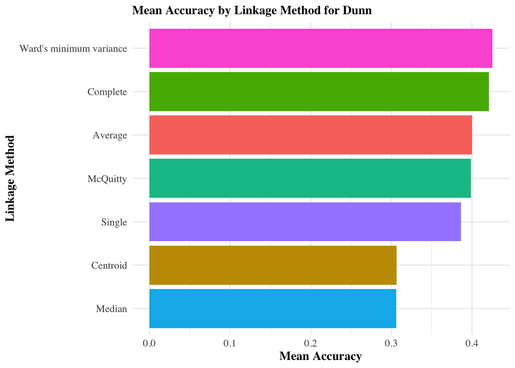

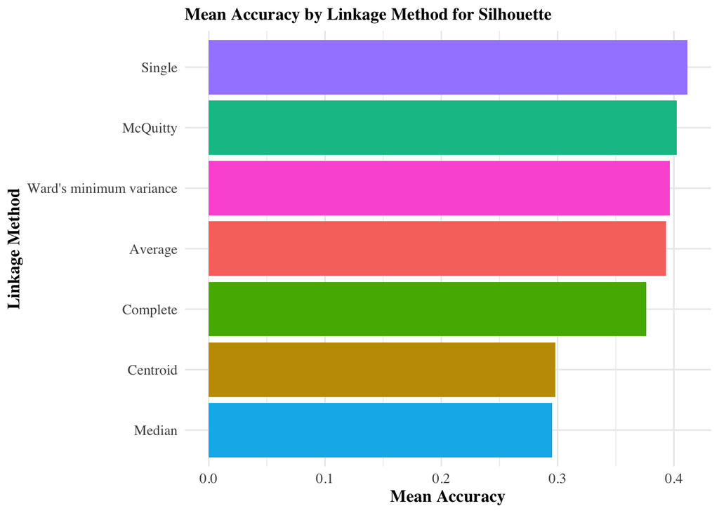

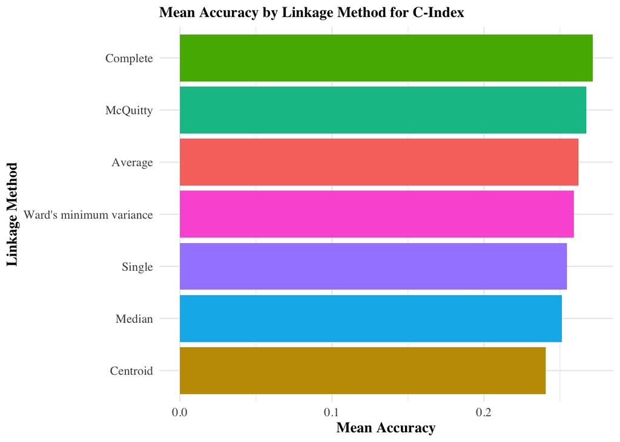

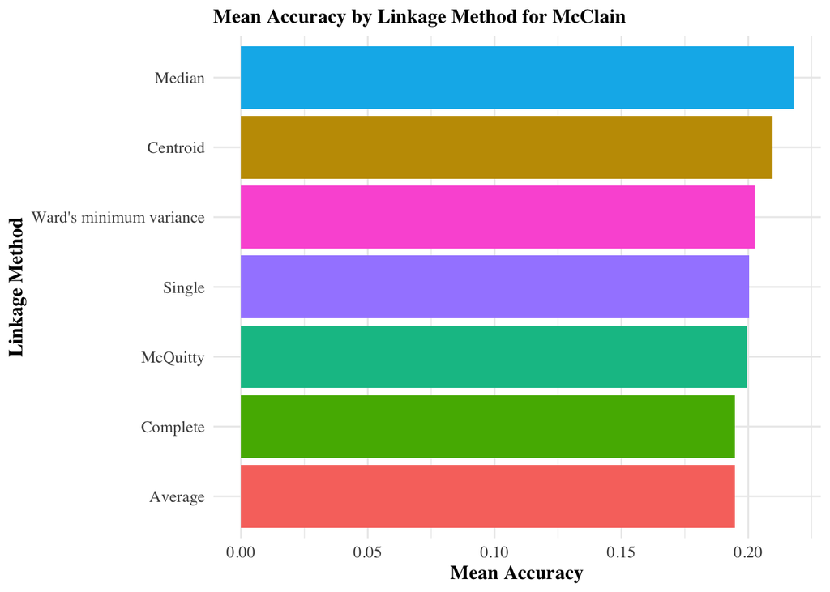

```r
# Plot 1: Bar charts by index — Mean Accuracy per Linkage Method
unique_indices <- combo_summary %>%
  distinct(index, .keep_all = TRUE) %>%  # keep one row per unique index
  filter(index != "mcclain", index != "cindex") %>%           # filter rows where mcclain and cindex are FALSE or 0
  pull(index)                            # get the index column as a vector
combo_summary <- combo_summary %>%
  filter(method != "median" & method != "centroid")
for (idx in unique_indices) {

  p <- combo_summary %>%
    filter(index == idx) %>%
    ggplot(aes(x = reorder(method, mean_accuracy), y = mean_accuracy, fill = method)) +
    geom_col() +
    coord_flip() +
    labs(title = paste("Mean Accuracy by Linkage Method for", tools::toTitleCase(idx)),
         x = "Linkage Method", y = "Mean Accuracy") +
    theme_minimal() +
    theme(legend.position = "none",
          plot.title = element_text(size = 12, face = "bold", family = "Times"),
          axis.title = element_text(size = 12, face = "bold", family = "Times"),
          axis.text = element_text(size = 10, family = "Times"))

print(p)

ggsave(paste0("1m_accuracy_", idx, ".pdf"), plot = p, width = 6, height = 4, units = "in")
}
```